# Homework 06: Data wrangling wrap up

# Loading libraries

First, we load the necessary libraries

# Character data: Read adn work the exercises in the [Strings chapter](https://r4ds.had.co.nz/strings.html) of R for data science

## Exercise 14.2.5:

- Question 1: In code that doesn’t use stringr, you’ll often see `paste()` and `paste0()`. What is the difference between the two functions? What stringr function are ther equivalent to ? How do the functions differ in their handling of `NA`?

Let us start by checking how the functions `paste()` and `paste0()` work;

```r
paste("Mango","Orange","Banana")
```

```
[1] "Mango Orange Banana"
```

Observe that the `paste()` function concatenate strings and separate them by space. It makes a single string from a collection of strings.

```r
paste0("Mango","Orange","Banana")
```

```
[1] "MangoOrangeBanana"
```

while the `paste0()` function concatenate the strings without space between them.

Let us determine which `stringr` functions are equivalent to the `paste()` and `paste0()`

```r
str_c("Mango","Orange","Banana")
```

```
[1] "MangoOrangeBanana"
```

This shows that the function `str_c()` in stringr is equivalent to the `paste0()` function

```r
str_c("Mango","Orange","Banana", sep = " ")
```

```
[1] "Mango Orange Banana"
```

And also the `str_c()` function when used as shown above is equivalent to the `paste()` function. Let us check how these function handle `NA`;

```r
StringS
```

```
[1] NA
```

```r
StringSA
```

```
[1] NA
```

Question 2: In your own words, describe the difference between the `sep` and `collapse` arguments to `str_c()`

```r
str_c("Mango","Orange","Banana", sep = "$") # separate the strings with a dollar sign
```

```
[1] "Mango$Orange$Banana"
```

The `sep` argument is used to specifies what you want to use to separate the strings. For instance, I have shown that we can separate the strings with space

```r
str_c("Mango","Orange","Banana", collapse =".")
```

```
[1] "MangoOrangeBanana"
```

The `collapse` argument is used to combine the strings together without any space between them.

Question 3: Use `str_length()` and `str_sub()` to extract the middle character from a string. What will you do if the string has an even even number of character?

```r
middle(x)
```

```
[1] "an"
```

Question 4: What does `str_wrap()` do? when might you want to use it?

```r
cat(str_wrap(string_data, width = 2))
```

```
these are just string for example Mango Orange Banana these are just string for example Mango these are just string for example Mango Orange Banana example Mango these are just string for example Mango Orange
```

```r
cat(str_wrap(string_data, width =50))
```

[output not shown]

# Writing functions

We shall be using the Gapminder data set for this exercise.

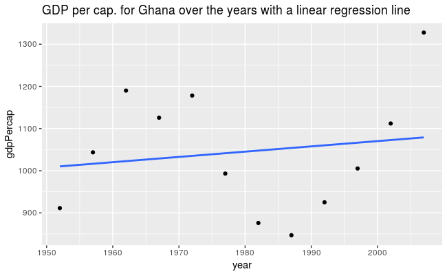

- Multiple linear regression

```r
linear_fit(gapminder,"Canada")
```

```
  (Intercept)       lifeExp           pop
-6.069152e+04  8.476864e+02  8.015472e-04
```

- Quadratic fit

```r
Quadratic_fit(gapminder,"Ghana")
```

```
 (Intercept)      lifeExp I(lifeExp^2)
 4203.305482  -124.935172     1.219996
```

| country | continent | year | lifeExp | pop | gdpPercap |
| --- | --- | --- | --- | --- | --- |
| Nigeria | Africa | 1952 | 36.324 | 33119096 | 1077.282 |
| Nigeria | Africa | 1957 | 37.802 | 37173340 | 1100.593 |
| Nigeria | Africa | 1962 | 39.360 | 41871351 | 1150.927 |
| Nigeria | Africa | 1967 | 41.040 | 47287752 | 1014.514 |
| Nigeria | Africa | 1972 | 42.821 | 53740085 | 1698.389 |
| Nigeria | Africa | 1977 | 44.514 | 62209173 | 1981.952 |
| Nigeria | Africa | 1982 | 45.826 | 73039376 | 1576.974 |
| Nigeria | Africa | 1987 | 46.886 | 81551520 | 1385.030 |
| Nigeria | Africa | 1992 | 47.472 | 93364244 | 1619.848 |
| Nigeria | Africa | 1997 | 47.464 | 106207839 | 1624.941 |

[output cut: 2 more lines]

```r
x <- c("abduahdjd","huihjahdaaha","main street")
str_sub(x,1,3)
```

[output not shown]

```r
x <- c("aAKSJS","JNKSSandaha","main street")
y <- str_to_lower(str_sub(x,1,1))
str_sub(y,1,1)
```

[output not shown]

```r
str_to_upper(c("i","l"),locale = "en")
```

[output not shown]